# Final Project Submission - Week 13

Chee Ting

2023-10-16

### **Week 9**

1. The topic that I have chosen for this project will be “Inflation”. For this project, I will be investigating inflation rates worldwide and most importantly Singapore, analysing its global trends and the factors contributing to its rise or fall.
2. The data sources that I have curated so far are Inflation data by International Monetary Fund and Core Inflation of Singapore by Monetary Authority of Singapore.

### **Week 10**

1. Why is inflation happening in Singapore?
- According to Monetary Authority Singapore, inflation affects many areas of the economy hence there is a need to understand inflation to secure a low and stable inflation in the Singapore economy over time.
- Singapore has the second highest inflation rate in 2023 among the ASEAN 5 countries according to the data provided by International Monetary Fund.
- Inflation in Singapore has been persistently growing according to data from Monetary Authority Singapore.
3. For the dataset “Inflation_world”, I will be using the columns of ‘region’ and ‘Inflation_rate’.

```
## # A tibble: 214 × 2
##    Country             Inflation_rate
##    <chr>                        <dbl>
##  1 Afghanistan                   NA
##  2 Albania                        4.8
##  3 Algeria                        9
##  4 Andorra                        5.2
##  5 Angola                        13.1
##  6 Antartica                     NA
##  7 Antigua and Barbuda            5
##  8 Argentina                    122.
##  9 Armenia                        3.5
## 10 Aruba                          4.5
## # ℹ 204 more rows
```

For the dataset “ASEAN_5_IMF”, I will be using the columns of ‘Year’, ‘Inflation_rate’ and ‘Country’.

```
## # A tibble: 115 × 3
##     Year Inflation_Rate Country
##    <dbl>          <dbl> <chr>
##  1  2001           11.5 Indonesia
##  2  2002           11.9 Indonesia
##  3  2003            6.8 Indonesia
##  4  2004            6.1 Indonesia
##  5  2005           10.5 Indonesia
##  6  2006           13.1 Indonesia
##  7  2007            6.3 Indonesia
##  8  2008            9.9 Indonesia
##  9  2009            4.8 Indonesia
## 10  2010            5.1 Indonesia
## # ℹ 105 more rows
```

For the dataset “weights_goods”, I will be using the columns of ‘Weights’ and ‘Goods’.

```
## # A tibble: 11 × 2
##    Goods                           Weights
##    <chr>                             <dbl>
##  1 Food excl Food Serving Services     682
##  2 Food Serving Services              1428
##  3 Clothing & Footwear                 212
##  4 Housing & Utilities                2484
##  5 Household Durables & Services       493
##  6 Health Care                         655
##  7 Transport                          1707
##  8 Communication                       411
##  9 Recreation & Culture                789
## 10 Education                           663
## 11 Miscellaneous Goods & Services      476
```

```
## # A tibble: 108 × 3
##    Quarterly C_P_I Goods
##    <chr>     <dbl> <chr>
##  1 2021Q2     102. ALL ITEMS
##  2 2021Q3     102. ALL ITEMS
##  3 2021Q4     104. ALL ITEMS
##  4 2022Q1     106. ALL ITEMS
##  5 2022Q2     108. ALL ITEMS
##  6 2022Q3     110. ALL ITEMS
##  7 2022Q4     111. ALL ITEMS
##  8 2023Q1     112  ALL ITEMS
##  9 2023Q2     113. ALL ITEMS
## 10 2021Q2     104  Food excl Food Serving Services
## # ℹ 98 more rows
```

One challenge I faced was to clean and format the dataset such that R can read my data. For example, in the dataset “ASEAN_5_IMF”, ‘country’ and ‘year’ were initally in rows instead of columns and hence R was not able to read and produce the result that I want. It took me a very long time trying to figure out the problem and find the best way to edit the Excel to get the end result. Another challenge I faced was to think of the question that I want to answer. The question cannot be too broad or too narrow as it will affect the rest of my data story. Therefore, to think of one, I need to exercise forward thinking and plan how the rest of my project will turn out so that I can achieve an organised data story that make sense.

### **Week 11**

Question 1:

1. Choropleth Map (Inflation Rate of every country) - To illustrate that inflation rate is a worldwide issue and hence shows the importance for inflation to be tackled.
2. Multiple Line graph to compare the trend between the ASEAN 5 countries (X: Year, Y: Inflation Rate) - To show how Singapore has the second highest inflation rate in 2023 among the ASEAN 5 countries
3. Pie Chart (Consumer Price Inflation (CPI) Weights of each goods or service) - To show the relative importance of each good or service in the basket.
4. Multiple Line graph to compare the trend of CPI between the different type of goods in Singapore (X: Year, Y: CPI) - Compare the average price changes of a goods and services over time and determine which goods or services fluctuate the most.

Question 2:

1. Choropleth Map: Shiny & Leaflet
- A world map that shows and compare the inflation rates of every country using different degree of colors. User is allowed to zoom in and out of the map
2. Multiple Line graph: Shiny
- Select input menu that allow users to choose the countries that they want to plot.
- Slider to allow the user to choose the year interval
3. Pie Chart: Shiny
- Slider to allow the user to choose the year that they want to visualise
4. Multiple Line graph: Shiny
- Select input menu that allow users to choose the type of goods that they want to plot.
- Slider to allow the user to choose the year interval

Question 3:

```
## # A tibble: 5 × 2
##   Concepts          Week
##   <chr>             <chr>
## 1 Choropleth map    NA
## 2 Slider            8
## 3 Select input menu NA
## 4 Line graph        NA
## 5 Pie-chart         NA
```

Challenges:

As I was planning on how my datasets can come together to form a data story, I realised that it is very difficult to answer the question that i have set last week as my datasets are too specific for that question. Hence, I have decided to change my question to: Which types of goods and services will make the most significant impact on households during inflation?

When I was considering how interactive I want my data to be, I found it challenging to envision the ideal format for my data visualisations. Striking the right balance was difficult, as it cannot be too simple and at the same time too complex for me to code. In light of this situation, I decided to explore various data visualisations and interactive options available on the internet. Eventually, I identified the most suitable ones that aligned with my specific needs and preferences.

### **Week 12**

The main challenge that I faced this week was when I made modifications to my Shiny app and attempted to re-publish it, an error unexpectedly occurred. Despite multiple attempts, both on my own and with the assistance of TAs, the cause of the problem became clear only after some time. It was determined that the error was due to my wrong placement of the data files, rendering them undetectable by Shiny.

### **Final Submission**

1. **Theme**: Inflation

   **Question**: Which types of goods and services will make the most significant impact on households during inflation in Singapore?
2. **Importance of addressing inflation**

Inflation has emerged as a worldwide issue ever since the pandemic and the Russia-Ukraine war which has caused supply chain disruptions.

In December of the previous year, Singapore secured the top spot as the most expensive city in the world (Economist Intelligence Unit, 2022). Singapore’s core inflation also reached 5.4% Year-on-Year Growth in the first quarter of 2023 (Monetary Authority Singapore, 2023).

Inflation can lead to a decline in the purchasing power of families, particularly impacting the standards of living for low-income families who are facing difficulty in meeting basic living expenses, thereby exerting adverse effects on their mental and physical well-being. Therefore, it is important to identify the specific goods or services that will make a huge impact on households in Singapore, so that policymakers can formulate targeted solutions and strategies, aiming to rectify the issue and restore inflation rates to more sustainable levels.

3. **How does the datasets answer my question**

The Global inflation data illustrates the different inflation rates across countries, emphasising the widespread nature of the issue that has to be tackled.

The ASEAN-5 dataset compares the inflation rates of the 5 countries over time. This is to illustrate the approximate time frame that led to the most recent inflation spike as well as to determine the position of Singapore’s inflation rate as compared to its neighbouring countries.

The CPI (Consumer Price Index) data measures the average price changes in a fixed basket of goods and services commonly purchased by households over time. From this data, we will be able to pinpoint the specific goods and services that have experienced notable price hikes.

The CPI weights data, derived from the Household Expenditure Survey, offer insights into the consumption patterns of households. The CPI weights indicate the relative importance of each item, averaged for all households, providing a comprehensive understanding of the goods and services most significantly impacted by rising prices.

By analysing the CPI data and weights data, we can pinpoint the goods and services households spend the most on and have recently undergone substantial price increases. This allows us to identify the specific items that will have the most significant impact on households during inflation in Singapore.

4. **Insights and depiction of data**

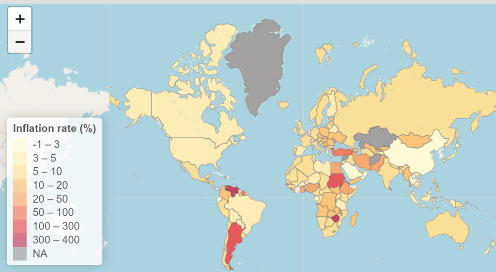

   Source: International Monetary Fund, 2023

The Choropleth map above provides a visual representation of global inflation rates using colors to depict varying levels. A majority of the countries have an average inflation rate falling within the 5-10% range, reiterating the widespread nature of the issue that needs to be tackled.

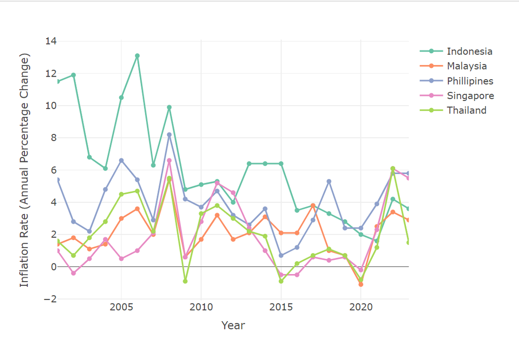

Source: International Monetary Fund, 2023

The line graph illustrates a comparison of inflation rates among the ASEAN-5 countries. All countries experienced a surge in their inflation starting from 2020. In 2023, Singapore is placed 2nd among the ASEAN nations.

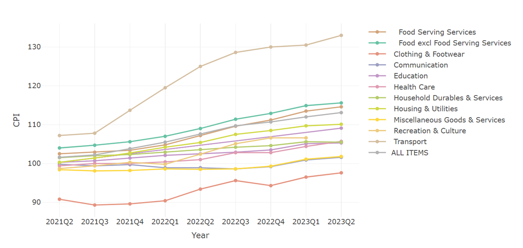

Source: Department of Statistics Singapore, 2023

This line graph depicts a comparison of CPI among the goods and services. Within this category, Transport experienced the most significant surge in prices, followed by Food excluding food serving services and Food serving services.

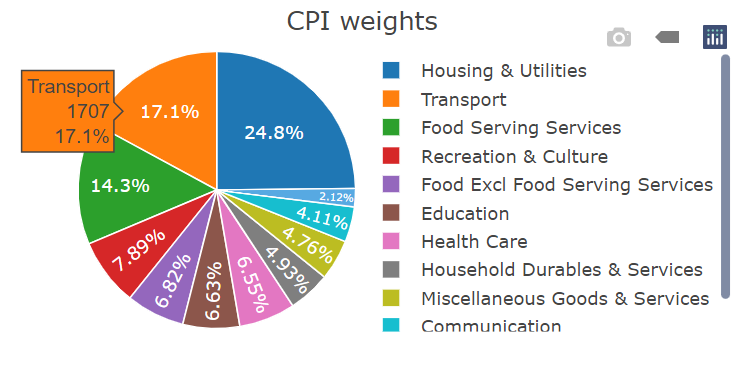

Main Categories

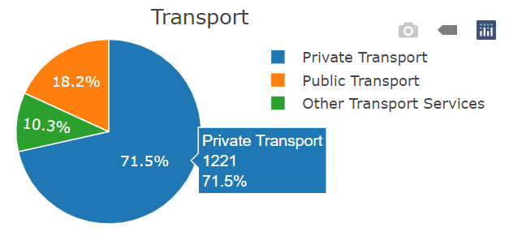

Sub-categories of Transport

Source: Department of Statistics Singapore, 2023

Based on all the data given, we can justify that Transport and Food serving services will make the most significant impact on households during inflation as both are ranked one of the highest in terms of CPI and household expenditures.

This is further proven as global economies reopened after the Covid-19 pandemic, demand rebounded strongly as consumers were eager to make purchases they had deferred during the pandemic, causing demand-pull inflation. However, supply could not match the rapid demand surge due to lingering restrictions that caused a shortage in supply. Hence, leading to the rise in prices of global food and energy commodities, when demand is more than supply. Additionally, the conflict between Russia and Ukraine war disrupted the global supply, even contributing to cost-pull inflation. The higher energy and food prices drove up electricity, transport and import costs for consumers and businesses globally, including Singapore (Monetary Authority of Singapore, 2023)

5. **Implementation and New Concepts**

Firstly, I started by researching the topics that I was interested in. Given my current major in Economics, I choose to focus on Inflation, a subject familiar to me so that I can leverage my existing knowledge and ensure a deeper understanding of the concepts involved.

Once the topic was determined, I gathered relevant datasets for my data story, ultimately selecting four datasets. The first 2, Global Inflation data and ASEAN5 data are used to illustrate the importance of addressing my chosen topic. The latter 2, CPI and CPI weights, are used to address my question.

For the Global Inflation data, I aimed to create a choropleth map illustrating the diverse inflation rates worldwide through different degrees of colours. To achieve this, I incorporated Leaflet to Shiny, a whole new concept for me. The process of figuring out the codes was challenging, but ultimately rewarding as I successfully implemented the visualisation.

Moving on to the ASEAN-5 and CPI datasets, both involved the plotting of line graphs to compare inflation trends among countries and goods and services. To enhance user interaction, I integrated slider functionality in Shiny, allowing users to select their desired periods for comparison. Additionally, the Select Input function enabled users to choose specific countries, goods, and services, introducing another aspect that was previously unfamiliar to me.

I also incorporated a drill-down pie chart for the CPI weights data. The pie chart displays the CPI weights broken by the main categories. User can further click into each category to read data of their respective sub-categories to understand what the main categories consist of. Additionally, a “Back button” is included to allow users to move back to the main data by clicking the button.

To enhance the overall aesthetics and user experience of the website, I integrated the card function, layout_sidebar and bslib package in Shiny. These features enabled users to easily access the interactive features that they can control, contributing to a more organised and visually appealing presentation of the data on my webpage.

**Reference**

Department of Statistics Singapore (2023). SingStat Table Builder. Retrieved November 12, 2023, from https://tablebuilder.singstat.gov.sg/table/TS/M213151

Economic Intelligience Unit. (2022). New York and Singapore rank as the world’s most expensive cities. Retrieved November 12, 2023, from https://www.eiu.com/n/new-york-and-singapore-rank-as-the-worlds-most-expensive-cities/

International Monetary Fund (2023). Datasets. Retrieved November 13, 2023, from https://www.imf.org/external/datamapper/datasets

Monetary Authority of Singapore (2023). Inflation was high in 2022. Retrieved November 13, 2023, from https://www.mas.gov.sg/monetary-policy/economics-edu-inflation/inflation/inflation-was-high-in-2022

Monetary Authority of Singapore (2023). MAS Core Inflation and Notes to Selected CPI Categories. Retrieved November 23, 2023, from https://www.mas.gov.sg/statistics/mas-core-inflation-and-notes-to-selected-cpi-categories